# Supervised Learning III

## Visualize Tuning Process

Visualize the tuning process using a `ggplot` for each of the two tuned hyperparameters.

**Hint 1:**

Performance results of the 3-fold CV for each configuration could be viewed via the `achive$data` field of the `AutoTuner`. Use e.g. the `ggplot()` function to analyze the relationship of the hyperparameter values and the performance values `classif.ce`.

**Hint 2:**

```r
library("ggplot2")
archive = glrn_tuned$...
ggplot(archive, aes(x = ..., y = ...)) +
  geom_boxplot()

ggplot(archive, aes(x = ..., y = classif.ce, col = ...)) +
  geom_line()

ggplot(archive, aes(x = ..., y = ..., fill = classif.ce)) +
  geom_tile()
```

### Solution:

**Click me:**

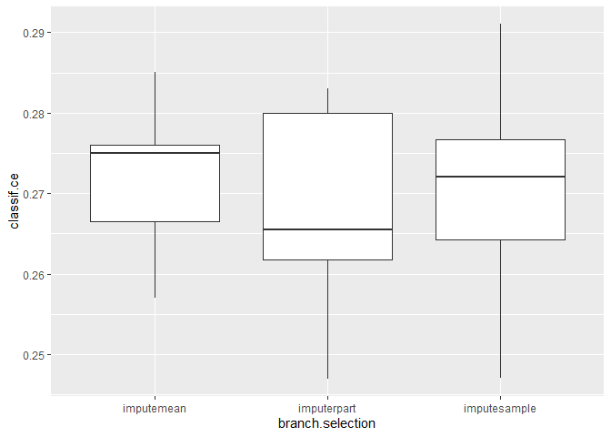

```r
library(ggplot2)
archive = glrn_tuned$archive$data

ggplot(archive, aes(x = branch.selection, y = classif.ce)) +
  geom_boxplot()
```

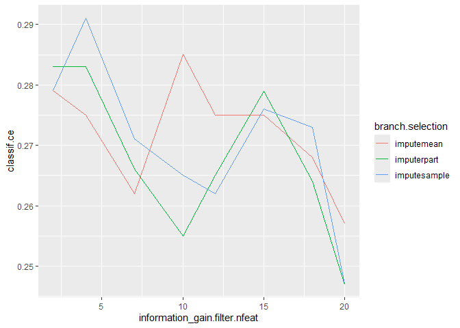

```r
ggplot(archive, aes(x = information_gain.filter.nfeat, y = classif.ce, col = branch.selection)) +
  geom_line()
```

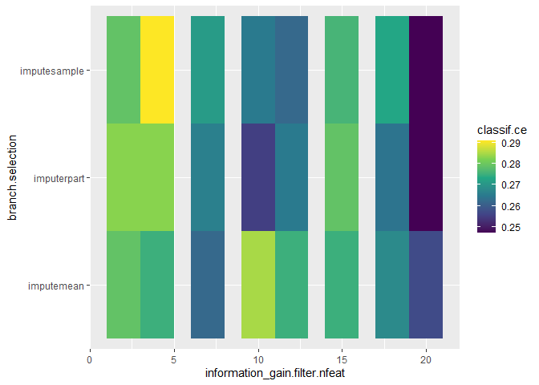

```r
ggplot(archive,
  aes(x = information_gain.filter.nfeat, y = branch.selection, fill = classif.ce)) +
  geom_tile() +
  scale_fill_viridis_c()
```

## Extract the best HPs

Which of the hyperparameter combination was the best performing one?

**Hint:**

You can either inspect the plots in the previous exercise or you can have a look on the `$tuning_result` field of the trained `AutoTuner`.

### Solution:

**Click me:**

```r
glrn_tuned$tuning_result
```

```
##    information_gain.filter.nfeat branch.selection learner_param_vals  x_domain classif.ce
##                            <int>           <char>             <list>    <list>      <num>
## 1:                            20      imputerpart          <list[5]> <list[2]>    0.24699
```

## Benchmark

Benchmark the previous `AutoTuner` (which automatically sets the best hyperparameters of the ML pipeline) against a decision tree (using its default hyperparameter values). Use 3-fold cross-validation.

**Hint:**

```r
lrns = list(...)
design = benchmark_grid(tasks = ..., learners = ..., resamplings = ...)
bmr = benchmark(...)
bmr$aggregate()
autoplot(bmr)
```